# quarto-inputdbf372c497bf1efe

# 4. Análise das variáveis

O comportamento de cada variável numérica foi analisado por meio de recursos gráficos e de um resumo estatístico dos dados.

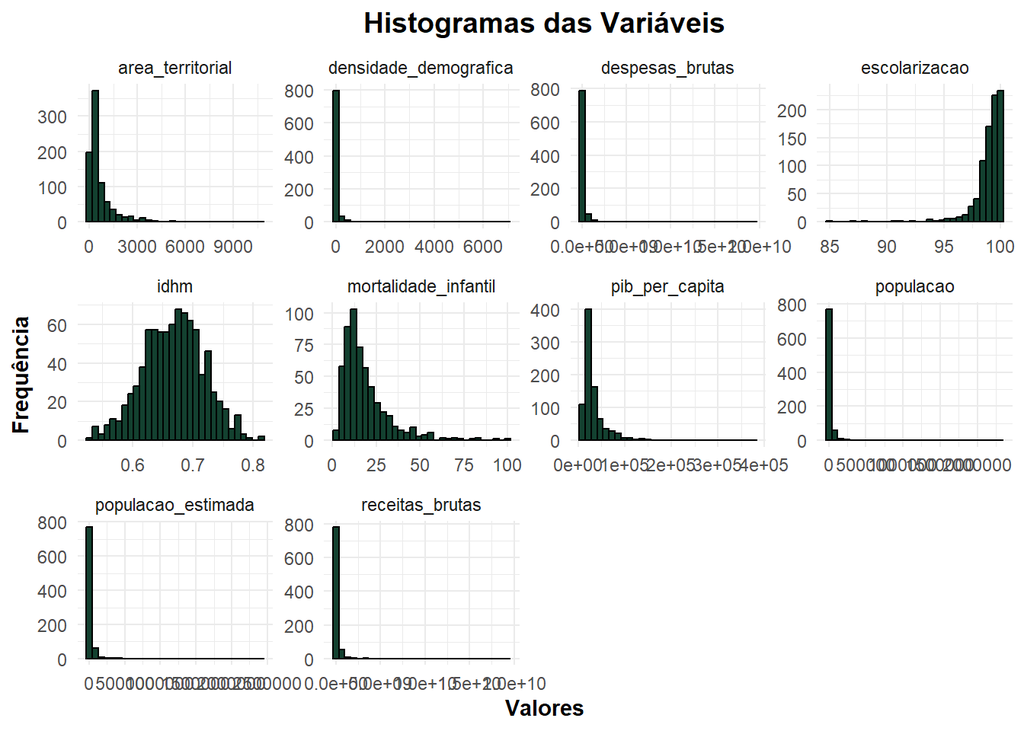

Figura 1: Histograma de todas as variáveis

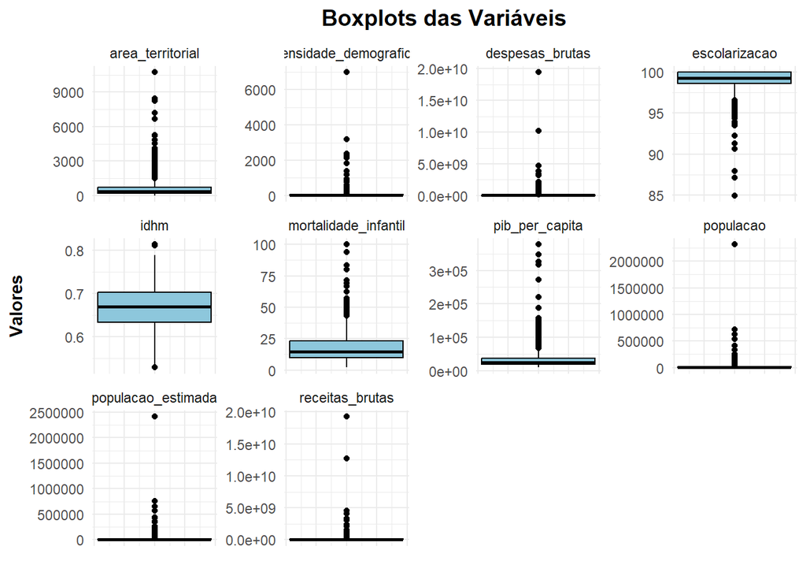

Figura 2: Boxplot de todas as variáveis

Na primeira etapa, os recursos visuais utilizados foram o histograma (gráfico de barras que representa a distribuição de frequências de dados contínuos) e o boxplot (diagrama de caixas). A partir deles, é possível observar a variação de frequência de cada variável e visualizar a discrepância entre os dados, o que facilita a identificação de possíveis valores atípicos chamados de outliers.

Tabela 1: Medidas-resumo das variáveis

| Variável | Média | Mediana | CV (%) |
| --- | --- | --- | --- |
| Área Territorial (km²) | 687,59 | 363,82 | 140,47 |
| População (Censo 2022) | 24.079,71 | 8.048,00 | 391,84 |
| Densidade Demográfica (hab/km²) | 69,09 | 22,09 | 455,11 |
| População Estimada (2025) | 25.080,24 | 8.237,00 | 393,82 |
| Escolarização 6-14 anos (%) | 98,99 | 99,29 | 1,37 |
| IDHM | 0,67 | 0,67 | 7,43 |
| Mortalidade Infantil (óbitos/1000) | 18,66 | 14,51 | 73,58 |
| Receitas Brutas (R$) | 181.973.241,86 | 56.697.158,96 | 468,44 |
| Despesas Brutas (R$) | 173.396.898,73 | 52.487.344,35 | 471,28 |
| PIB per Capita (R$) | 34.487,09 | 24.727,70 | 96,62 |

Tabela 2: Valores mínimos e máximos por variável

| Variável | Mínimo | Município..Mín. | Máximo | Município..Máx. |
| --- | --- | --- | --- | --- |
| Área Territorial (km²) | 3,56 | Santa Cruz de Minas | 1,072710e+04 | João Pinheiro |
| População (Censo 2022) | 833,00 | Serra da Saudade | 2,315560e+06 | Belo Horizonte |
| Densidade Demográfica (hab/km²) | 1,21 | Santa Fé de Minas | 6,988180e+03 | Belo Horizonte |
| População Estimada (2025) | 856,00 | Serra da Saudade | 2,415872e+06 | Belo Horizonte |
| Escolarização 6-14 anos (%) | 84,92 | Simão Pereira | 1,000000e+02 | Água Comprida |
| IDHM | 0,53 | São João das Missões | 8,100000e-01 | Nova Lima |
| Mortalidade Infantil (óbitos/1000) | 1,95 | Monte Carmelo | 1,000000e+02 | Cachoeira Dourada |
| Receitas Brutas (R$) | 1.582.348,32 | Bandeira do Sul | 1,929010e+10 | Belo Horizonte |
| Despesas Brutas (R$) | 21.904.283,86 | Tapiraí | 1,942099e+10 | Belo Horizonte |
| PIB per Capita (R$) | 9.139,92 | São João das Missões | 3,777906e+05 | Extrema |

Já na segunda etapa, realizou-se um resumo estatístico para sinalizar a média, a mediana (valor que ocupa a posição central dos dados) e o coeficiente de variação (tabela 1). Este último indica o quanto os dados variam em relação à média, de modo que um valor baixo sinaliza pequena dispersão, enquanto um valor alto indica uma grande dispersão dos dados.Além disso, foi possível encontrar o máximo e mínimo de cada variável (tabela 2).

## 4.1 Área territorial

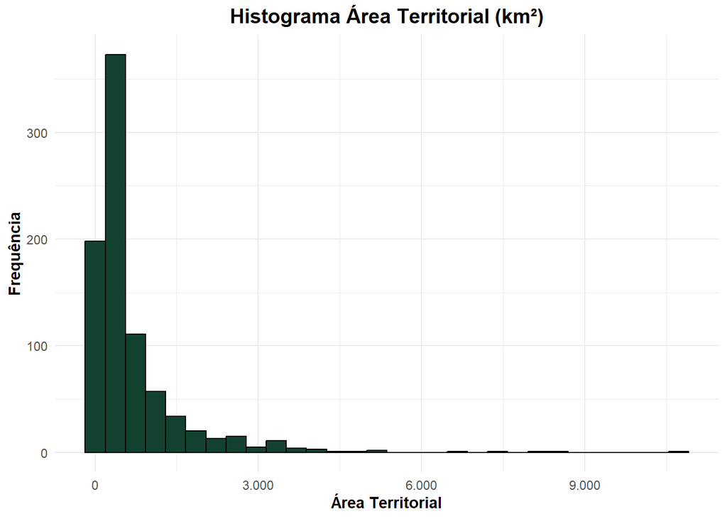

Figura 3: Histograma área territorial

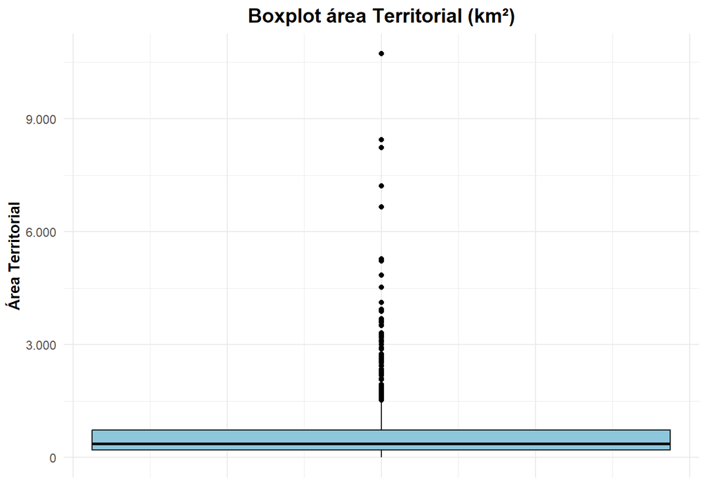

Figura 4: Boxplot área territorial

O gráfico de histograma deixa evidente que há uma maior concentração de área territorial entre os primeiros 1500 km2. Isso significa que há uma distribuição fortemente assimétrica à direita, em que uma grande massa de dados está localizada no início do gráfico (à esquerda), enquanto o restante do gráfico forma uma cauda longa em direção aos valores mais altos (à direita). Isso reflete a realidade geográfica do estado de Minas Gerais, já que ele é composto por uma enorme quantidade de municípios de pequeno porte territorial.

É importante ressaltar que o gráfico de boxplot reforça essa concentração de dados em cidades de área menor, tendo em vista que sua caixa é mais achatada e demonstra como os valores estão próximos entre si. Além do mais, embora pudesse ser visto no gráfico anterior, nesse torna-se mais evidente a quantidade de outliers no conjunto dados, que é representando pelos pontos pretos fora da caixa. Por fim, a linha preta horizontal que corta a caixa representa a mediana da área territorial, que se posiciona bem próxima de zero. Isso confirma que 50% dos municípios possuem extensões territoriais muito reduzidas. O fato de a distância entre a mediana e o topo da caixa (3º quartil) ser visivelmente maior do que a distância até a base (1º quartil) reforça numericamente a forte assimetria que foi detectada no histograma, mostrando que a dispersão dos dados é muito maior entre as maiores cidades do que entre as menores.

Esse comportamento é completamente coerente com o cálculo das medidas de resumo dessa variável (tabela 1), que resultou nos seguintes valores:

Média: 687,59

Mediana: 363,82

Coeficiente de variação: 140,47%

Como a área média é maior que a mediana, é possível concluir que a maior parte dos dados se concentram em valores mais baixos, o que conclui novamente que Minas possui uma grande quantidade de municípios pequenos, enquanto uma menor parte tem muito mais extensão territorial. Além disso, nota-se que coeficiente de variação indica que esses valores possuem uma dispersão muito alta em relação à média, reforçando a grande heterogeneidade do estado.

## 4.2 População

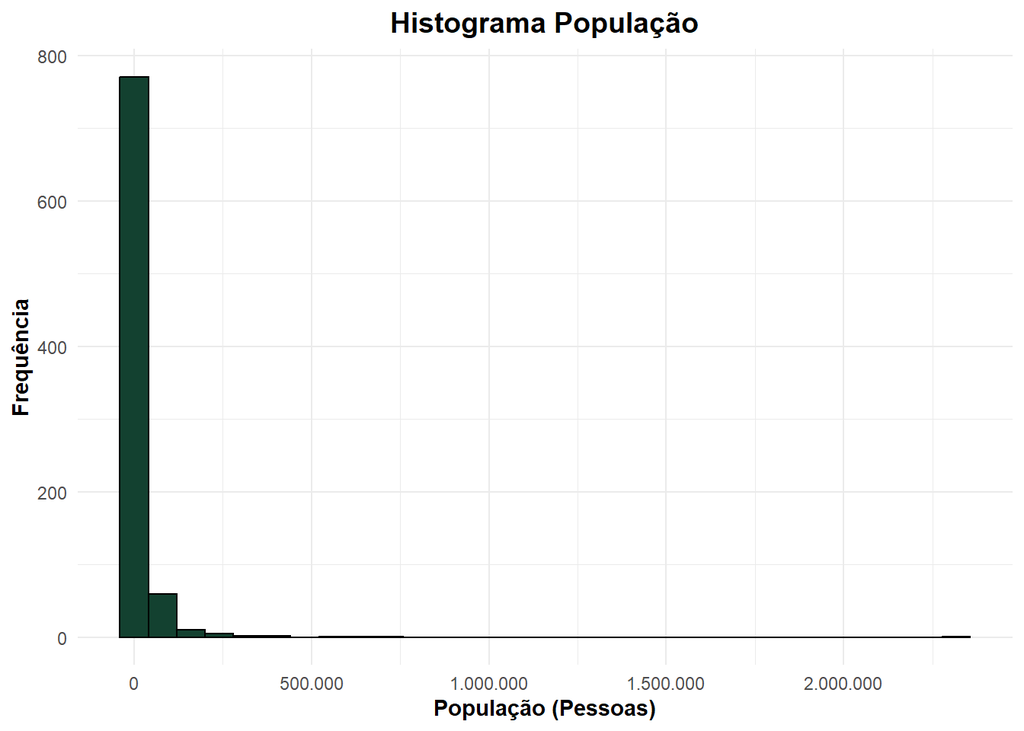

Figura 5: Histograma população

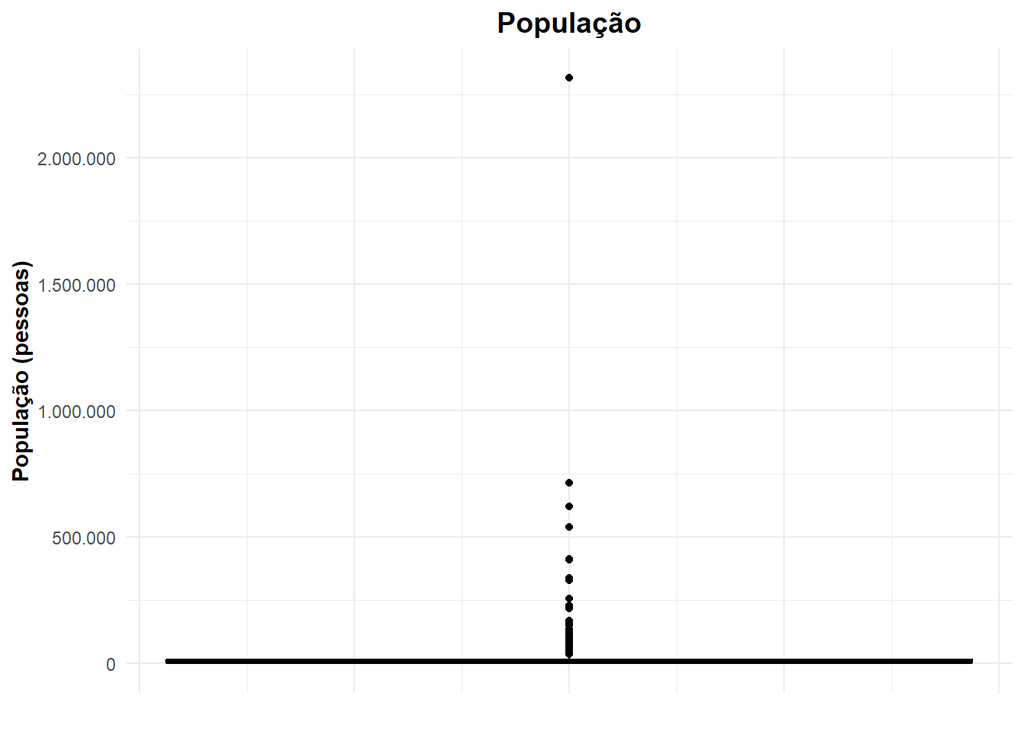

Figura 6: Boxplot população

O gráfico de histograma deixa evidente que há uma maior concentração de população nas faixas iniciais. Isso significa que há uma distribuição fortemente assimétrica à direita, em que a significativa massa de dados está localizada no lado esquerdo do gráfico, enquanto o restante forma uma cauda longa e quase imperceptível em direção aos valores mais altos. Esse comportamento reflete a demografia do estado, que é composta principalmente por muitos municípios com populações muito pequenas.

Ademais, é notório como o gráfico de boxplot reforça essa concentração extrema de dados a partir de uma caixa completamente achatada na base do gráfico, a qual demonstra onde a maior parte dos valores está. Além do mais, o boxplot torna evidente a enorme quantidade de outliers no conjunto de dados, representados pelos pontos pretos acima da caixa fina. A título de curiosidade, o ponto mais isolado no topo do gráfico que ultrapassa a marca de 2 milhões de habitantes representa a capital Belo Horizonte, reforçando a discrepância populacional de Minas Gerais.

Esse comportamento é completamente coerente com o cálculo das medidas de resumo dessa variável (tabela 1), que resultou nos seguintes valores:

Média: 24.079,71

Mediana: 8.048

Coeficiente de variação: 391,84%

O coeficiente de variação indica uma dispersão extremamente alta para os valores da população entre os municípios de Minas Gerais. Novamente, a média maior do que a mediana (proporção de três vezes mais) indica que metade das cidades de Minas possui 8.048 cidadãos ou menos no momento observado.

## 4.3 Densidade demográfica

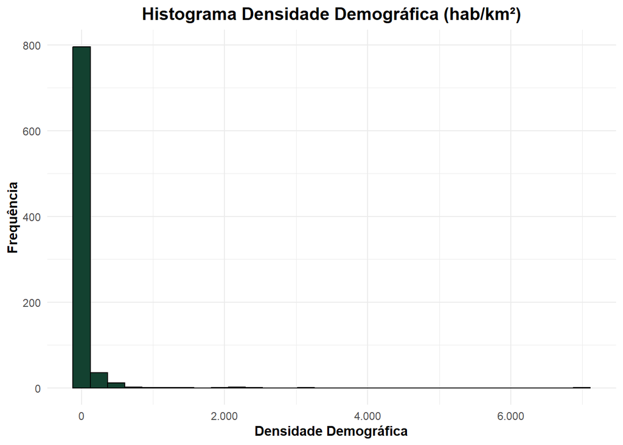

Figura 7: Histograma densidade demográfica

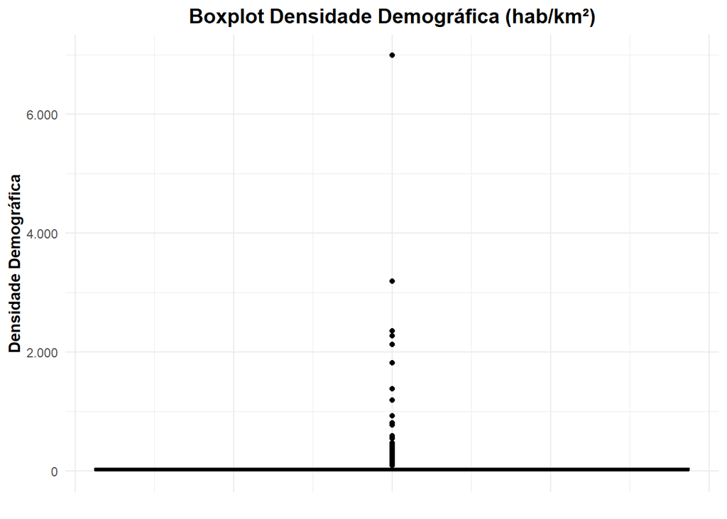

Figura 8: Boxplot densidade demográfica

O gráfico de histograma evidencia uma maior concentração de densidade demográfica nas faixas iniciais. Em suma, há uma distribuição fortemente assimétrica à direita, de modo que a grande massa de dados está localizada no lado esquerdo do gráfico, enquanto o restante forma uma cauda longa e quase imperceptível em direção aos valores mais altos. Esse comportamento reflete a ocupação territorial do estado, que é composta principalmente por muitos municípios com concentrações de habitantes muito pequenas por quilômetro quadrado.

O gráfico de boxplot reforça essa concentração extrema de dados a partir de uma caixa completamente achatada na base do gráfico, a qual demonstra onde a maior parte dos valores está. Além do mais, o boxplot torna evidente a enorme quantidade de outliers no conjunto de dados, representados pelos pontos pretos acima da caixa fina. A título de curiosidade, o ponto mais isolado no topo do gráfico que ultrapassa a marca de 6.000 hab/km² representa a capital Belo Horizonte, reforçando a discrepância de adensamento urbano de Minas Gerais.

Esse comportamento é completamente coerente com o cálculo das medidas de resumo dessa variável (tabela 1), que resultou nos seguintes valores:

Média: 69,09

Mediana: 22,09

Coeficiente de variação: 455,11%

## 4.4 População estimada

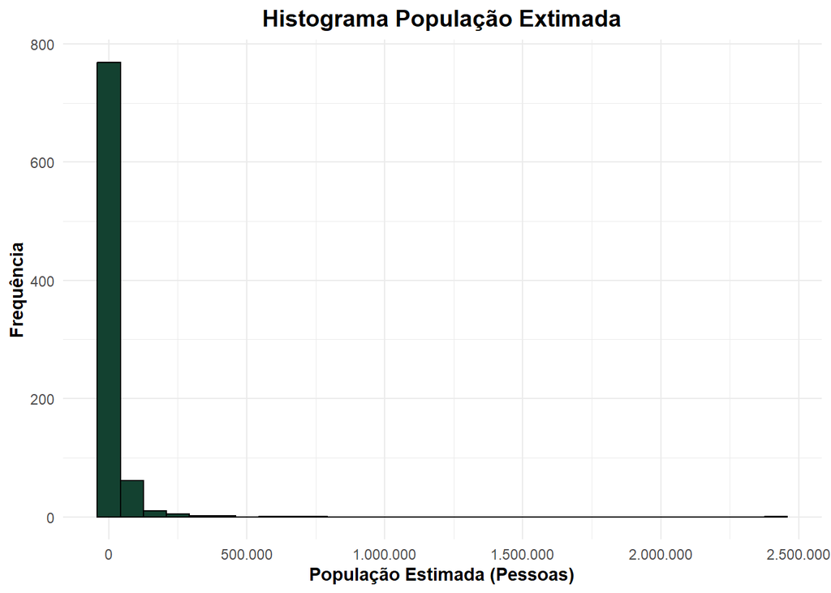

Figura 9: Histograma população estimada

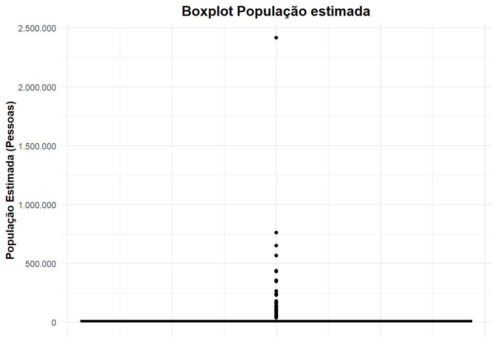

Figura 10: Boxplot população estimada

A leitura do histograma revela um cenário similar às variáveis anteriores, de modo que a distribuição dos dados se concentra fortemente logo na parte inicial do gráfico. Esse padrão significa que há uma distribuição fortemente assimétrica à direita, em que a significativa massa de dados está localizada no lado esquerdo do gráfico, enquanto o restante forma uma cauda longa e quase imperceptível em direção aos valores mais altos. Tal configuração traduz a perspectiva demográfica mineiro a qual é delimitada por uma vasta quantidade de municípios de pequeno porte populacional.

Olhando para o boxplot, nota-se como ele reforça essa concentração extrema de dados por meio de uma caixa completamente achatada na base, que demonstra onde a maior parte dos valores está agrupada. Além do mais, esse gráfico torna evidente a enorme quantidade de outliers no conjunto de dados, representados pelos pontos pretos acima da caixa fina. A título de curiosidade, de forma similar à última análise, o ponto mais isolado no topo do gráfico que ultrapassa a marca de 2 milhões de habitantes representa a estimativa para a capital Belo Horizonte, reforçando a discrepância populacional de Minas Gerais.

Esse comportamento é completamente coerente com o cálculo das medidas de resumo dessa variável (tabela 1), que resultou nos seguintes valores:

- Média: 25.080,24
- Mediana: 8.237
- Coeficiente de variação: 393,82%

De forma similar à última análise, o coeficiente de variação é extremamente alto. É possível concluir que a população estimada na maioria das cidades é relativamente menor do que em uma pequena quantidade de outros municípios.

## 4.5 Escolarização

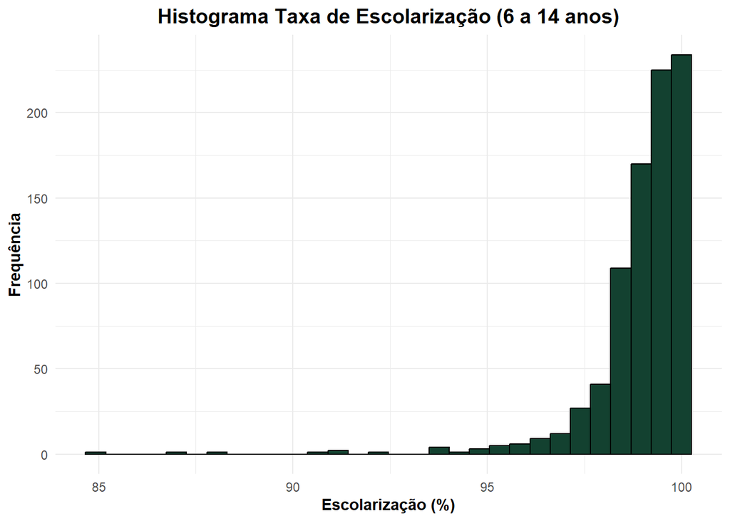

Figura 11: Histograma escolarização

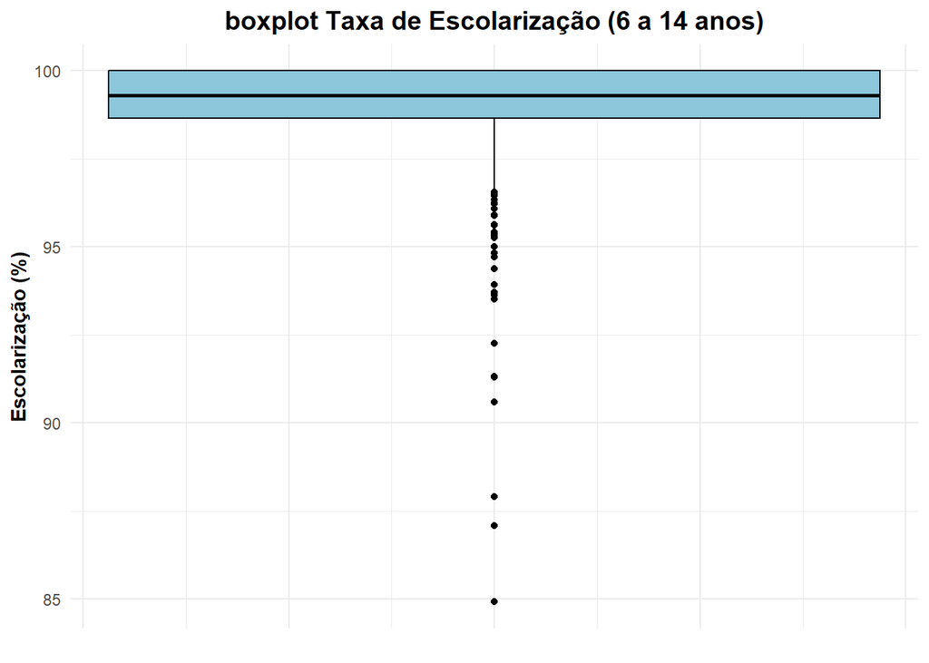

Figura 12: Boxplot escolarização

O gráfico de histograma deixa evidente que há uma maior concentração da taxa de escolarização nas faixas finais, bem próximas de 100%. Isso significa que, ao contrário das variáveis anteriores, há uma distribuição fortemente assimétrica à esquerda, em que a significativa massa de dados está localizada no lado direito do gráfico, enquanto o restante forma uma cauda longa em direção aos valores mais baixos. Esse comportamento reflete que a grande maioria dos municípios do estado possui índices de escolarização infantil bastante elevados.

Ademais, é notório como o gráfico de boxplot reforça essa concentração extrema de dados na parte superior, apresentando uma caixa localizada no topo do gráfico, a qual demonstra onde a maior parte dos valores está concentrada. A linha preta horizontal que corta essa caixa representa a mediana (99,29%) e, por estar posicionada tão próxima ao limite superior, confirma que pelo menos metade dos municípios mineiros possui índices de escolarização quase totalmente universalizados. Além do mais, o boxplot torna evidente que os outliers, representados pelos pontos pretos, aparecem desta vez abaixo da caixa. Esse formato indica que os municípios discrepantes do conjunto de dados são aqueles que possuem taxas de escolarização abaixo do padrão do estado, chegando a marcas próximas de 85%.

Esse comportamento é completamente coerente com o cálculo das medidas de resumo dessa variável (tabela 1), que resultou nos seguintes valores:

Média: 98,99%

Mediana: 99,29%

Coeficiente de variação: 1,37%

## 4.6 IDHM

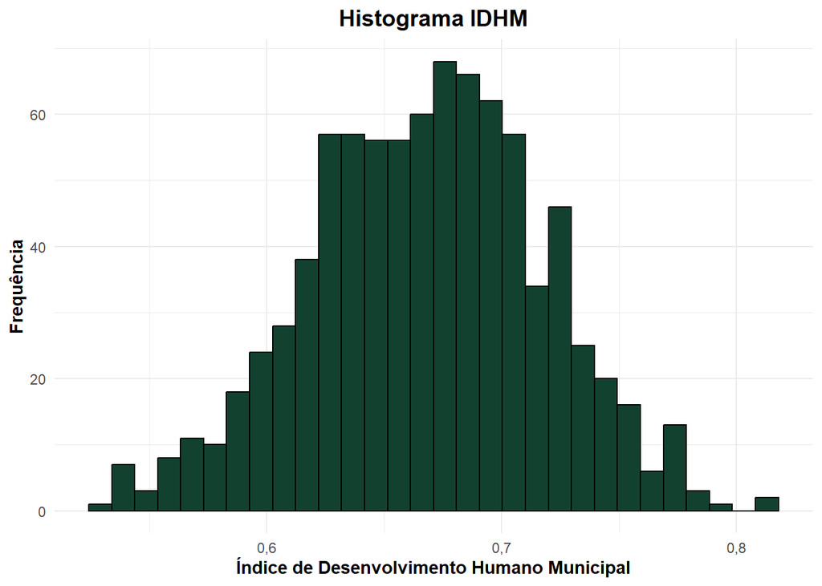

Figura 13: Histograma IDHM

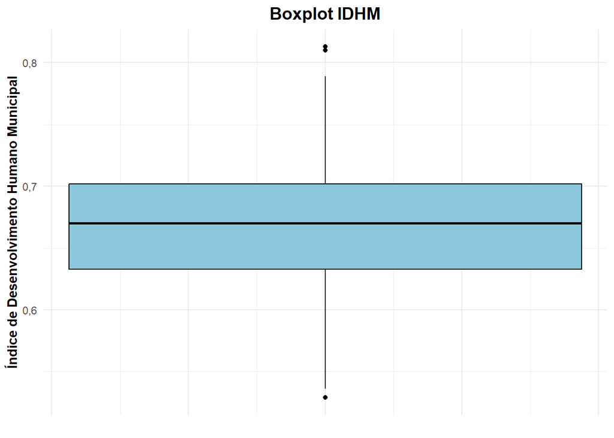

Figura 14: Boxplot IDHM

O gráfico de histograma deixa evidente que há uma distribuição bem distribuída e equilibrada, praticamente simétrica, de modo que a significativa massa de dados está localizada no centro do gráfico (em torno de 0,6 e 0,7), enquanto as frequências vão diminuindo de forma parecida tanto em direção aos valores mais baixos (à esquerda) quanto aos valores mais altos (à direita). Esse comportamento reflete que a maior parte dos municípios mineiros compartilha de um patamar médio de desenvolvimento humano.

Esse comportamento é completamente coerente com o cálculo das medidas de resumo dessa variável (tabela 1), que resultou nos seguintes valores:

Média: 0,67

Mediana: 0,67

Coeficiente de variação: 7,43%

Os valores de média e mediana iguais confirmam que os dados se apresentam de forma simétrica. O coeficiente de variação de 7,43% indica que existe pouca variação entre os dados, ou seja, apesar das desigualdades observadas nas outras variáveis, o IDHM se mantem relativamente estável.

## 4.7 Mortalidade infantil

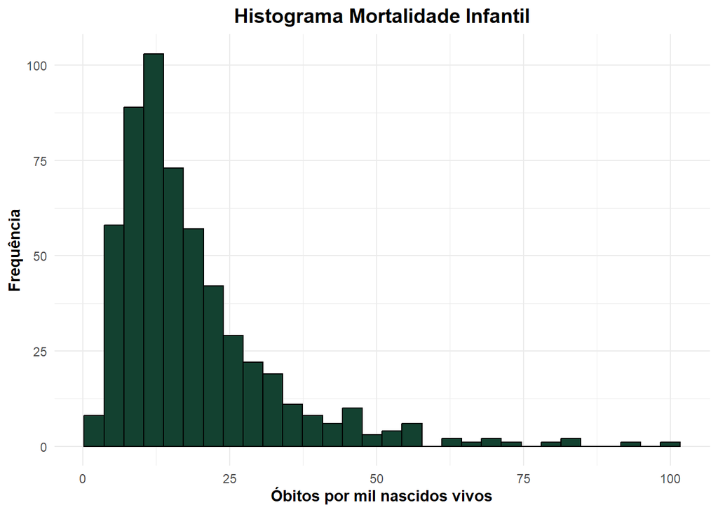

Figura 15: Histograma mortalidade infantil

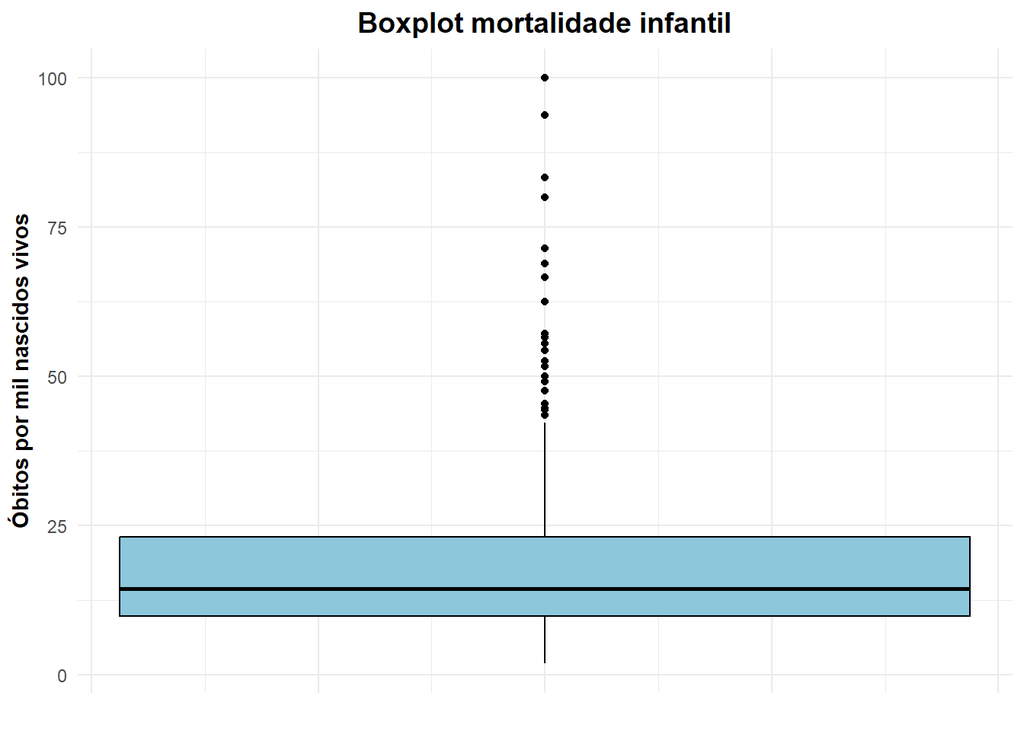

Figura 16: Boxplot mortalidade infantil

O gráfico de histograma deixa evidente que há uma maior concentração de taxas de mortalidade infantil nas faixas iniciais, com o pico principal ocorrendo entre 10 e 15 óbitos por mil nascidos vivos. Isso significa que há uma distribuição assimétrica à direita, em que a maior parte da massa de dados está localizada no lado esquerdo do gráfico, enquanto o restante forma uma cauda longa que vai se estendendo em direção aos valores mais altos. Esse comportamento reflete que, embora a maioria dos municípios mineiros apresente índices de mortalidade mais controlados, ainda há uma parcela de cidades em patamares agravantes.

Ademais, nota-se como o gráfico de boxplot reforça essa assimetria. Diferente de outras variáveis, a caixa não se apresenta totalmente achatada na base, indicando uma dispersão moderada entre os municípios comuns. A linha preta horizontal que corta a caixa representa a mediana e o fato de ela estar mais próxima da base da caixa reforça graficamente a assimetria à direita. Além do mais, esse gráfico torna evidente a quantidade de outliers no conjunto de dados, representados pelos pontos pretos acima do limite superior, chamando a atenção para municípios isolados onde o índice chega a atingir a alarmante marca de até 100 óbitos por mil nascidos vivos.

Esse comportamento é completamente coerente com o cálculo das medidas de resumo dessa variável (tabela 1), que resultou nos seguintes valores:

Média: 18,66

Mediana: 14,51

Coeficiente de variação: 73,58%

O alto coeficiente de variação confirma que os dados são distribuídos de forma não homogênea. A média maior que a mediana reforça assimetria à direita, com algumas poucas cidades tendo uma taxa de mortalidade infantil mais distantes da média, refletindo essa desigualdade.

## 4.8 Receitas/Despesas brutas

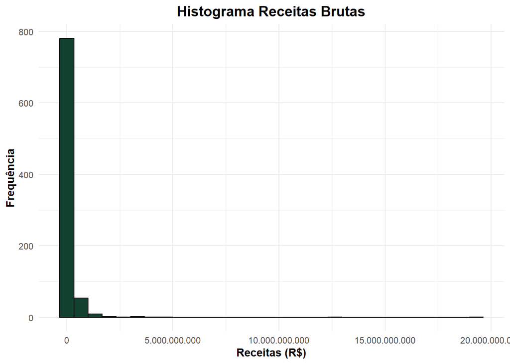

Figura 17: Histograma Receitas brutas

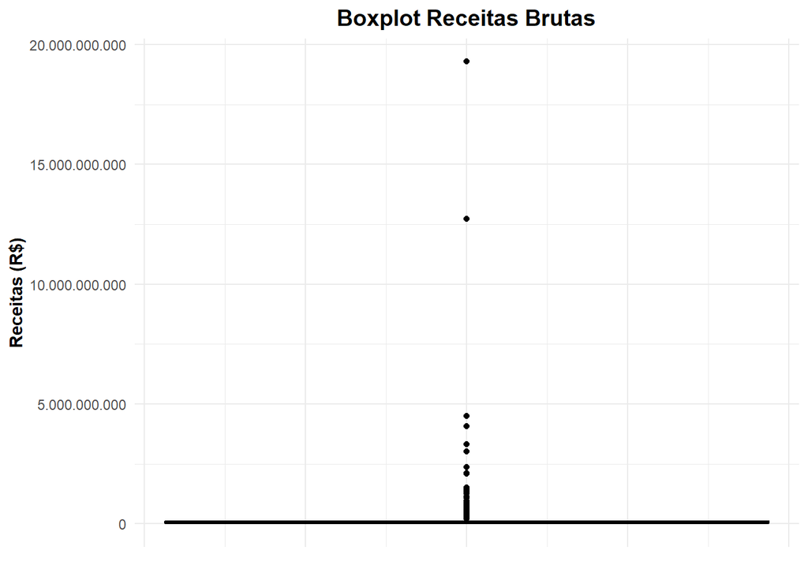

Figura 18: Boxplot Receitas brutas

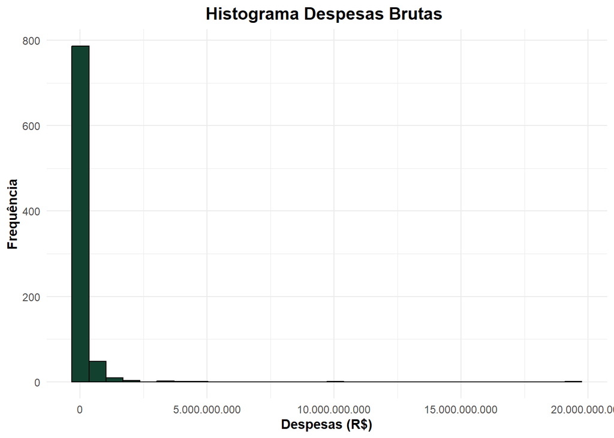

Figura 19: Histograma Despesas brutas

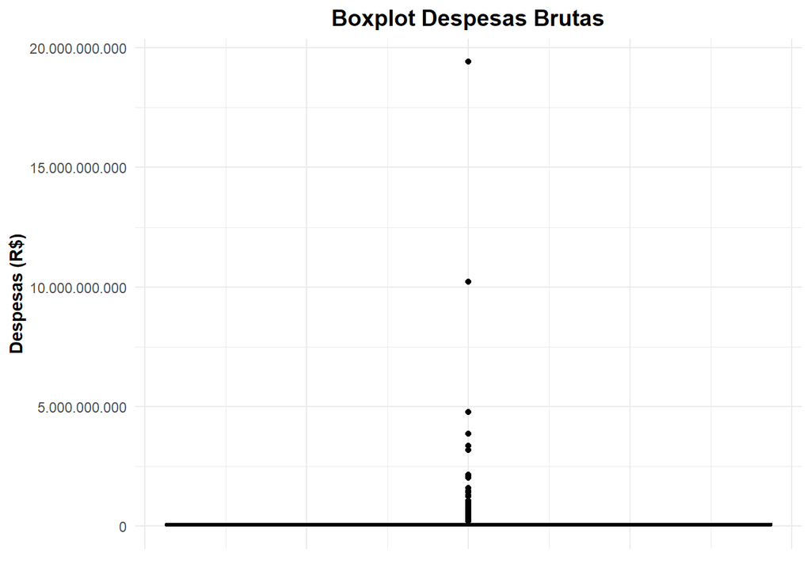

Figura 20: Boxplot Despesas brutas

O gráfico de histograma deixa evidente que há uma maior concentração tanto de receitas quanto de despesas brutas nas faixas iniciais. Isso significa que há uma distribuição fortemente assimétrica à direita, em que a significativa massa de dados está localizada no lado esquerdo do gráfico, enquanto o restante forma uma cauda longa e quase imperceptível em direção aos valores mais altos. Esse comportamento reflete a realidade orçamentária do estado, evidenciando que a grande maioria dos municípios mineiros opera com volumes de recursos financeiros muito pequenos.

Ademais, é notório como o gráfico de boxplot reforça essa concentração extrema de dados a partir de uma caixa completamente achatada na base do gráfico, a qual demonstra onde a maior parte dos valores orçamentários está. Além do mais, o boxplot torna evidente a enorme quantidade de outliers no conjunto de dados, representados pelos pontos pretos acima da caixa fina que se estendem verticalmente de forma expressiva. A título de curiosidade, os pontos mais isolados no topo do gráfico, que chegam a superar a marca de 15 bilhões de reais, representam os valores associados à capital Belo Horizonte, reforçando a brutal discrepância e a centralização de recursos econômicos em Minas Gerais.

Esse comportamento é completamente coerente com o cálculo das medidas de resumo dessas variáveis (tabela 1), que resultaram nos seguintes valores:

Médias: 181mi/173mi

Medianas: 56mi/52mi

Coeficientes de variação: 468%/471%

Esses valores reforçam que existe uma distribuição extremamente desigual do orçamento mineiro. 50% dos municípios possuem renda/despesa na faixa de 50 milhões, no entanto, a média está na faixa de 180 milhões, o que indica que poucas cidades concentram uma movimentação de recursos financeiros fortemente maior.

## 4.9 PIB per capita

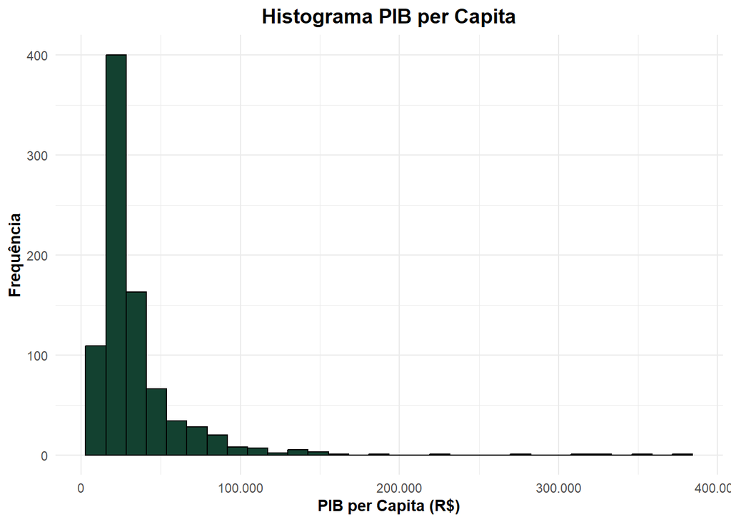

Figura 21: Histograma PIB per capita

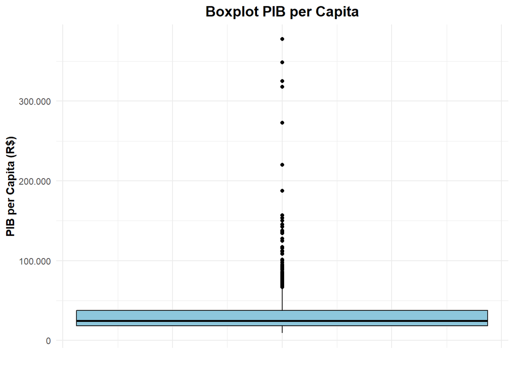

Figura 22: Boxplot PIB per capita

O gráfico de histograma deixa evidente que há uma maior concentração de valores de PIB per capita nas faixas iniciais, com o maior volume de municípios se situando entre 15.000 e 30.000 reais. Isso significa que há uma distribuição assimétrica à direita, em que a significativa massa de dados está localizada no lado esquerdo do gráfico, enquanto o restante forma uma cauda que se estende de maneira contínua em direção aos valores mais altos. Esse comportamento reflete a realidade econômica do estado, mostrando que a maior parte das cidades mineiras opera em patamares de produção de riqueza por habitante relativamente modestos.

Ao analisar o gráfico de boxplot, nota-se como ele reforça essa tendência assimétrica. A caixa não se apresenta completamente achatada na base, indicando que existe uma dispersão interna considerável mesmo entre os municípios que compõem o corpo central dos dados. A linha preta horizontal que corta a estrutura representa a mediana (24.727,70) e, por estar deslocada para a porção inferior da caixa, confirma graficamente a assimetria. Além do mais, o boxplot torna evidente a presença de outliers no conjunto de dados, representados pelos pontos pretos posicionados acima do limite superior, evidenciando cidades com forte atividade econômica concentrada onde o PIB per capita chega a ultrapassar a marca dos 200.000 reais.

Esse comportamento é completamente coerente com o cálculo das medidas de resumo dessa variável (tabela 1), que resultou nos seguintes valores:

Média: 34.487,09

Mediana: 24.727,70

Coeficiente de variação: 96,62%

Essa análise corrobora com a última ao, através de um alto coeficiente de variação, mostrar que os dados se distribuem de forma assimétrica, ou seja, algumas poucas cidades concentram valores de PIB per capita muito maiores do que a maioria, criando a disparidade entre média e mediana.